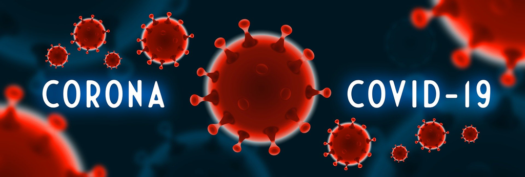

Note: Datasets are up to 04/25/22

# Covid Introduction

Covid-19 is a respiratory illness caused by SARS-CoV-2, a coronavirus that was first discovered in Wuhan China in December of 2019. The coronavirus spreads through air droplets that are released when a person coughs, sneezes, talks, or simply breathes. Symptoms include cough, fever, chills, aches, headache, fatigue, congestion, and loss of taste and smell. Though symptoms are usually mild, severe illness resulting in hospitalization and death is possible, especially for older individuals or people with underlying conditions. The spread of Covid-19 caused a pandemic in the United States (and the world). In the United States, most Covid-19 policies and procedures were instituted at a state level. Additionally, people's background (age, ethnicity, religion, political affiliation, etc.) played a large role in how cautious they were with avoiding the disease. In this work, we examine the per-capita covid cases in each state and examine which demographic factors have explanatory power over these trends. This will hopefully explain the demographic factors that caused both personal decisions on how to respond to the pandemic as well as policy decisions in certain states. The knowledge of these demographic trends could influence future policy decisions related to public health policy. Apart from demographics we also want to answer the question of how well the US did compare to the rest of the world. This can give us insight on how well our policies and lockdowns helped suppress the spread of COVID-19.

An important thing to note is that we'll only look at the 50 states in the US and so we'll be ignoring other US owned territories such as Puerto Rico, Guam, Northern Mariana Islands, the U.S. Virgin Islands, and American Samoa.

## Data Collection/Curation

```python
import pandas as pd, matplotlib.pyplot as plt, numpy as np, seaborn as sns, re, datetime
```

The John's Hopkins curated dataset can be found [here](https://github.com/CSSEGISandData/COVID-19). For our analysis, we'll be using the time series csv file for confirmed cases and deaths within the United States. Each dataset has a list of counties in the United States and lists the confirmed covid cases/deaths for the county on each day since the start of the pandemic (1/22/2020 for our purposes) up to April 25, 2022. The data comes from Johns Hopkins University's Covid-19 Data repository, one of the most well-respected sources for Covid-19 data in the world (and one of the most well-respected Universities in the world).

```python
confirmed_US = pd.read_csv("datasets/time_series_covid19_confirmed_US.csv")
confirmed_US['Admin2'] = confirmed_US['Admin2'].astype(str)

confirmed_US
```

|  | UID | iso2 | iso3 | code3 | FIPS | Admin2 | Province_State | Country_Region | Lat | Long_ | ... | 4/16/22 | 4/17/22 | 4/18/22 | 4/19/22 | 4/20/22 | 4/21/22 | 4/22/22 | 4/23/22 | 4/24/22 | 4/25/22 |
| --- | --- | --- | --- | --- | --- | --- | --- | --- | --- | --- | --- | --- | --- | --- | --- | --- | --- | --- | --- | --- | --- |
| 0 | 84001001 | US | USA | 840 | 1001.0 | Autauga | Alabama | US | 32.539527 | -86.644082 | ... | 15752 | 15752 | 15771 | 15755 | 15757 | 15759 | 15762 | 15762 | 15762 | 15814 |
| 1 | 84001003 | US | USA | 840 | 1003.0 | Baldwin | Alabama | US | 30.727750 | -87.722071 | ... | 55547 | 55547 | 55579 | 55564 | 55571 | 55576 | 55591 | 55591 | 55591 | 55607 |
| 2 | 84001005 | US | USA | 840 | 1005.0 | Barbour | Alabama | US | 31.868263 | -85.387129 | ... | 5658 | 5658 | 5659 | 5658 | 5658 | 5659 | 5660 | 5660 | 5660 | 5661 |
| 3 | 84001007 | US | USA | 840 | 1007.0 | Bibb | Alabama | US | 32.996421 | -87.125115 | ... | 6428 | 6428 | 6428 | 6428 | 6428 | 6428 | 6430 | 6430 | 6430 | 6435 |
| 4 | 84001009 | US | USA | 840 | 1009.0 | Blount | Alabama | US | 33.982109 | -86.567906 | ... | 14959 | 14959 | 14963 | 14961 | 14963 | 14967 | 14967 | 14967 | 14967 | 14967 |
| ... | ... | ... | ... | ... | ... | ... | ... | ... | ... | ... | ... | ... | ... | ... | ... | ... | ... | ... | ... | ... | ... |
| 3337 | 84056039 | US | USA | 840 | 56039.0 | Teton | Wyoming | US | 43.935225 | -110.589080 | ... | 9945 | 9945 | 9945 | 9975 | 9975 | 9975 | 9975 | 9975 | 9975 | 9975 |
| 3338 | 84056041 | US | USA | 840 | 56041.0 | Uinta | Wyoming | US | 41.287818 | -110.547578 | ... | 5624 | 5624 | 5624 | 5625 | 5625 | 5625 | 5625 | 5625 | 5625 | 5625 |
| 3339 | 84090056 | US | USA | 840 | 90056.0 | Unassigned | Wyoming | US | 0.000000 | 0.000000 | ... | 0 | 0 | 0 | 0 | 0 | 0 | 0 | 0 | 0 | 0 |
| 3340 | 84056043 | US | USA | 840 | 56043.0 | Washakie | Wyoming | US | 43.904516 | -107.680187 | ... | 2357 | 2357 | 2357 | 2357 | 2357 | 2357 | 2357 | 2357 | 2357 | 2357 |
| 3341 | 84056045 | US | USA | 840 | 56045.0 | Weston | Wyoming | US | 43.839612 | -104.567488 | ... | 1587 | 1587 | 1587 | 1587 | 1587 | 1587 | 1587 | 1587 | 1587 | 1587 |

3342 rows × 836 columns

The next step we have to do after importing our dataset is to check for null values. We want to handle missing data so that if there are any missing data it doesn't skew our findings.

```python
confirmed_US[confirmed_US.isna().any(axis=1)]
```

|  | UID | iso2 | iso3 | code3 | FIPS | Admin2 | Province_State | Country_Region | Lat | Long_ | ... | 4/16/22 | 4/17/22 | 4/18/22 | 4/19/22 | 4/20/22 | 4/21/22 | 4/22/22 | 4/23/22 | 4/24/22 | 4/25/22 |
| --- | --- | --- | --- | --- | --- | --- | --- | --- | --- | --- | --- | --- | --- | --- | --- | --- | --- | --- | --- | --- | --- |
| 1269 | 84070002 | US | USA | 840 | NaN | Dukes and Nantucket | Massachusetts | US | 41.406747 | -70.687635 | ... | 6865 | 6865 | 6865 | 6872 | 6882 | 6892 | 6894 | 6894 | 6894 | 6902 |
| 1306 | 84070005 | US | USA | 840 | NaN | Federal Correctional Institution (FCI) | Michigan | US | 0.000000 | 0.000000 | ... | 327 | 327 | 327 | 327 | 327 | 327 | 327 | 327 | 327 | 327 |
| 1338 | 84070004 | US | USA | 840 | NaN | Michigan Department of Corrections (MDOC) | Michigan | US | 0.000000 | 0.000000 | ... | 38290 | 38290 | 38290 | 38290 | 38294 | 38294 | 38294 | 38294 | 38294 | 38294 |
| 1593 | 84070003 | US | USA | 840 | NaN | Kansas City | Missouri | US | 39.099700 | -94.578600 | ... | 112687 | 112687 | 112687 | 112687 | 112687 | 112687 | 112687 | 112687 | 112687 | 112687 |
| 2956 | 84070015 | US | USA | 840 | NaN | Bear River | Utah | US | 41.521068 | -113.083282 | ... | 51544 | 51544 | 51544 | 51544 | 51544 | 51575 | 51575 | 51575 | 51575 | 51575 |
| 2961 | 84070016 | US | USA | 840 | NaN | Central Utah | Utah | US | 39.372319 | -111.575868 | ... | 20694 | 20694 | 20694 | 20694 | 20694 | 20699 | 20699 | 20699 | 20699 | 20699 |
| 2980 | 84070017 | US | USA | 840 | NaN | Southeast Utah | Utah | US | 38.996171 | -110.701396 | ... | 10053 | 10053 | 10053 | 10053 | 10053 | 10067 | 10067 | 10067 | 10067 | 10067 |
| 2981 | 84070018 | US | USA | 840 | NaN | Southwest Utah | Utah | US | 37.854472 | -111.441876 | ... | 63488 | 63488 | 63488 | 63488 | 63488 | 63559 | 63559 | 63559 | 63559 | 63559 |
| 2984 | 84070019 | US | USA | 840 | NaN | TriCounty | Utah | US | 40.124915 | -109.517442 | ... | 12731 | 12731 | 12731 | 12731 | 12731 | 12741 | 12741 | 12741 | 12741 | 12741 |
| 2992 | 84070020 | US | USA | 840 | NaN | Weber-Morgan | Utah | US | 41.271160 | -111.914512 | ... | 73802 | 73802 | 73802 | 73802 | 73802 | 73906 | 73906 | 73906 | 73906 | 73906 |

10 rows × 836 columns

We see that the only missing values are related to the FIPS code. However, we would not need the FIPS code as once we group each one of these counties by state, we won't be needing these codes. Therefore, we can safely ignore these missing values.

An observation to note is that the dataset above has each date as an individual column thus making the table too "wide". This in turn makes it harder in analyzing the date (albeit it's easier to read). We'll convert the table from the current wide format to a long format by turning each date column into their own row through a process called melting. More information about melting can be found [here](https://dataindependent.com/pandas/pandas-melt-pd-melt/).

```python
# finding index of first date
idx = next(x for x in confirmed_US.columns.values if (re.match('(\d{1,2})[/.-](\d{1,2})[/.-](\d{2})$', x)))
idx = np.where(confirmed_US.columns.values == idx)[0][0]

# melting our dataframe with our identifier variables being everything up to idx+3
confirmed_US = pd.melt(confirmed_US, id_vars=confirmed_US.columns[0:idx])
confirmed_US.rename(columns={"value": "Cases", "variable": "Date"}, inplace=True)
confirmed_US
```

|  | UID | iso2 | iso3 | code3 | FIPS | Admin2 | Province_State | Country_Region | Lat | Long_ | Combined_Key | Date | Cases |
| --- | --- | --- | --- | --- | --- | --- | --- | --- | --- | --- | --- | --- | --- |
| 0 | 84001001 | US | USA | 840 | 1001.0 | Autauga | Alabama | US | 32.539527 | -86.644082 | Autauga, Alabama, US | 1/22/20 | 0 |
| 1 | 84001003 | US | USA | 840 | 1003.0 | Baldwin | Alabama | US | 30.727750 | -87.722071 | Baldwin, Alabama, US | 1/22/20 | 0 |
| 2 | 84001005 | US | USA | 840 | 1005.0 | Barbour | Alabama | US | 31.868263 | -85.387129 | Barbour, Alabama, US | 1/22/20 | 0 |
| 3 | 84001007 | US | USA | 840 | 1007.0 | Bibb | Alabama | US | 32.996421 | -87.125115 | Bibb, Alabama, US | 1/22/20 | 0 |
| 4 | 84001009 | US | USA | 840 | 1009.0 | Blount | Alabama | US | 33.982109 | -86.567906 | Blount, Alabama, US | 1/22/20 | 0 |
| ... | ... | ... | ... | ... | ... | ... | ... | ... | ... | ... | ... | ... | ... |
| 2757145 | 84056039 | US | USA | 840 | 56039.0 | Teton | Wyoming | US | 43.935225 | -110.589080 | Teton, Wyoming, US | 4/25/22 | 9975 |
| 2757146 | 84056041 | US | USA | 840 | 56041.0 | Uinta | Wyoming | US | 41.287818 | -110.547578 | Uinta, Wyoming, US | 4/25/22 | 5625 |
| 2757147 | 84090056 | US | USA | 840 | 90056.0 | Unassigned | Wyoming | US | 0.000000 | 0.000000 | Unassigned, Wyoming, US | 4/25/22 | 0 |
| 2757148 | 84056043 | US | USA | 840 | 56043.0 | Washakie | Wyoming | US | 43.904516 | -107.680187 | Washakie, Wyoming, US | 4/25/22 | 2357 |
| 2757149 | 84056045 | US | USA | 840 | 56045.0 | Weston | Wyoming | US | 43.839612 | -104.567488 | Weston, Wyoming, US | 4/25/22 | 1587 |

2757150 rows × 13 columns

In addition to melting our data, our next step would be to convert each of the dates inside our dataframe to [datetime](https://docs.python.org/3/library/datetime.html) objects. These are objects supplied by the datetime module that allows us to easily perform comparison operations and range queries on dates. To make things easier, pandas has a method called `to_datetime()` that allows us to streamline this process.

```python
confirmed_US['Date'] = pd.to_datetime(confirmed_US['Date'], format="%m/%d/%y")
```

In this next step since we're not concerned about the cases from the county inside of each state but more about the total cases for the state itself. And so, we'll aggregate the cases in each state by adding up all the county cases.

```python
totalCases_US = confirmed_US.groupby(['Province_State', 'Date']).agg({'Cases': 'sum'})
totalCases_US.reset_index(inplace=True)
totalCases_US[(totalCases_US['Province_State'] == "Maryland") & (totalCases_US['Cases'] > 0)].head(10)
```

|  | Province_State | Date | Cases |
| --- | --- | --- | --- |
| 19844 | Maryland | 2020-03-06 | 3 |
| 19845 | Maryland | 2020-03-07 | 3 |
| 19846 | Maryland | 2020-03-08 | 5 |
| 19847 | Maryland | 2020-03-09 | 5 |
| 19848 | Maryland | 2020-03-10 | 8 |
| 19849 | Maryland | 2020-03-11 | 9 |
| 19850 | Maryland | 2020-03-12 | 12 |
| 19851 | Maryland | 2020-03-13 | 18 |
| 19852 | Maryland | 2020-03-14 | 27 |
| 19853 | Maryland | 2020-03-15 | 24 |

Now we have the total number of cases fo each state for each date. However, another metric we want is the number of daily cases each day which is defined by the total cases today minus the total cases yesterday.

We'll manipulate our dataframe so that we have an additional column called `daily_cases` defined as above. We'll take advatange of pandas's `diff()` function which allows us to compute the difference of a column between consecutive rows in one line. One issue with directly doing this is that at positions where we transition from one state to the next, we can have large negative values because `diff()` is subtracting the most recent total cases for one state from the oldest total cases for a different state. To circumvent this, we'll filter and perform the `diff()` separetly for each state.

```python
# getting a list of states in our dataset
states = np.unique(confirmed_US['Province_State'].values)
totalCases_US['daily_cases'] = np.NaN # instanstiating with default value of NaN

# iterating through each state
for s in states:
    filtered = totalCases_US.loc[totalCases_US['Province_State'] == s] # getting a separate  dataframe for each state
    totalCases_US.loc[totalCases_US['Province_State'] == s, 'daily_cases']= filtered['Cases'].diff() # adding daily_cases

totalCases_US[(totalCases_US['Province_State'] == "Maryland") & (totalCases_US['Cases'] > 0)].head(10)
```

|  | Province_State | Date | Cases | daily_cases |
| --- | --- | --- | --- | --- |
| 19844 | Maryland | 2020-03-06 | 3 | 3.0 |
| 19845 | Maryland | 2020-03-07 | 3 | 0.0 |
| 19846 | Maryland | 2020-03-08 | 5 | 2.0 |
| 19847 | Maryland | 2020-03-09 | 5 | 0.0 |
| 19848 | Maryland | 2020-03-10 | 8 | 3.0 |
| 19849 | Maryland | 2020-03-11 | 9 | 1.0 |
| 19850 | Maryland | 2020-03-12 | 12 | 3.0 |
| 19851 | Maryland | 2020-03-13 | 18 | 6.0 |
| 19852 | Maryland | 2020-03-14 | 27 | 9.0 |
| 19853 | Maryland | 2020-03-15 | 24 | -3.0 |

Now we have modified the Johns Hopkins dataset to give us the culmulative and daily cases grouped by date and state. However, just by itself this modified Johns Hopkins dataset is not all that useful if we want to discover underlying trends and associations in COVID cases. If all we had were the case/death counts we'll be limited in the scope of our findings. To amend this we'll import the first of many other datasets that contains demographic information about each US state in 2020.

Our first [dataset](https://corgis-edu.github.io/corgis/csv/state_demographics/) imported below summarizes information about each US state in 2016-2020 using information acquired from the [US Census Bureau](https://www.census.gov/quickfacts/fact/table/US/PST045221), the standard bearer for United States demographic data. This dataset does incorrectly name the 2020 population as the 2014 popuation (we compared the population in this column using the US Census website and it was indeed a misnaming). Therefore we will rename it to 2020 below. The data contains demographic information about each state including statistics related to population, age, ethnicity, gender, income, poverty rate, population density, etc.

```python
state_demographics = pd.read_csv("datasets/state_demographics.csv")
state_demographics.rename(columns={'Population.2014 Population':'Population.2020 Population'}, inplace=True)

state_demographics.head(10)
```

|  | State | Population.Population Percent Change | Population.2020 Population | Population.2010 Population | Age.Percent Under 5 Years | Age.Percent Under 18 Years | Age.Percent 65 and Older | Miscellaneous.Percent Female | Ethnicities.White Alone | Ethnicities.Black Alone | ... | Employment.Nonemployer Establishments | Employment.Firms.Total | Employment.Firms.Men-Owned | Employment.Firms.Women-Owned | Employment.Firms.Minority-Owned | Employment.Firms.Nonminority-Owned | Employment.Firms.Veteran-Owned | Employment.Firms.Nonveteran-Owned | Population.Population per Square Mile | Miscellaneous.Land Area |
| --- | --- | --- | --- | --- | --- | --- | --- | --- | --- | --- | --- | --- | --- | --- | --- | --- | --- | --- | --- | --- | --- |
| 0 | Connecticut | -10.2 | 3605944 | 3574097 | 5.1 | 20.4 | 17.7 | 51.2 | 79.7 | 12.2 | ... | 286874 | 326693 | 187845 | 106678 | 56113 | 259614 | 31056 | 281182 | 738.1 | 4842.36 |
| 1 | Delaware | 8.4 | 989948 | 897934 | 5.6 | 20.9 | 19.4 | 51.7 | 69.2 | 23.2 | ... | 68623 | 73418 | 38328 | 23964 | 14440 | 54782 | 7206 | 60318 | 460.8 | 1948.54 |
| 2 | District of Columbia | 17.3 | 689545 | 601723 | 6.4 | 18.2 | 12.4 | 52.6 | 46.0 | 46.0 | ... | 62583 | 63408 | 30237 | 27064 | 29983 | 29521 | 5070 | 54217 | 9856.5 | 61.05 |
| 3 | Florida | 14.2 | 21538187 | 18801310 | 5.3 | 19.7 | 20.9 | 51.1 | 77.3 | 16.9 | ... | 2388050 | 2100187 | 1084885 | 807817 | 926112 | 1121749 | 185756 | 1846686 | 350.6 | 53624.76 |
| 4 | Georgia | 9.6 | 10711908 | 9687653 | 6.2 | 23.6 | 14.3 | 51.4 | 60.2 | 32.6 | ... | 955621 | 929864 | 480578 | 376506 | 371588 | 538893 | 96787 | 800585 | 168.4 | 57513.49 |
| 5 | Hawaii | 4.1 | 1455271 | 1360301 | 6.0 | 21.2 | 19.0 | 50.0 | 25.5 | 2.2 | ... | 112589 | 118454 | 60409 | 44453 | 74208 | 38510 | 11148 | 101334 | 211.8 | 6422.63 |
| 6 | Alabama | 2.6 | 5024279 | 4779736 | 6.0 | 22.2 | 17.3 | 51.7 | 69.1 | 26.8 | ... | 336445 | 374153 | 203604 | 137630 | 92219 | 272651 | 41943 | 316984 | 94.4 | 50645.33 |
| 7 | Alaska | 3.0 | 733391 | 710231 | 7.0 | 24.6 | 12.5 | 47.9 | 65.3 | 3.7 | ... | 57391 | 68032 | 35402 | 22141 | 13688 | 51147 | 7953 | 56091 | 1.2 | 570640.95 |
| 8 | Arizona | 13.9 | 7151502 | 6392017 | 5.9 | 22.5 | 18.0 | 50.3 | 82.6 | 5.2 | ... | 502593 | 499926 | 245243 | 182425 | 135313 | 344981 | 46780 | 427582 | 56.3 | 113594.08 |
| 9 | Arkansas | 3.5 | 3011524 | 2915918 | 6.2 | 23.2 | 17.4 | 50.9 | 79.0 | 15.7 | ... | 209179 | 231959 | 123158 | 75962 | 35982 | 189029 | 25915 | 192988 | 56.0 | 52035.48 |

10 rows × 48 columns

```python
state_demographics.columns
```

```
Index(['State', 'Population.Population Percent Change',
       'Population.2020 Population', 'Population.2010 Population',
       'Age.Percent Under 5 Years', 'Age.Percent Under 18 Years',
       'Age.Percent 65 and Older', 'Miscellaneous.Percent Female',
       'Ethnicities.White Alone', 'Ethnicities.Black Alone',
       'Ethnicities.American Indian and Alaska Native Alone',
       'Ethnicities.Asian Alone',
       'Ethnicities.Native Hawaiian and Other Pacific Islander Alone',
       'Ethnicities.Two or More Races', 'Ethnicities.Hispanic or Latino',
       'Ethnicities.White Alone, not Hispanic or Latino',
       'Miscellaneous.Veterans', 'Miscellaneous.Foreign Born',
       'Housing.Housing Units', 'Housing.Homeownership Rate',
       'Housing.Median Value of Owner-Occupied Units', 'Housing.Households',
       'Housing.Persons per Household',
       'Miscellaneous.Living in Same House +1 Years',
       'Miscellaneous.Language Other than English at Home',
       'Housing.Households with a computer',
       'Housing.Households with a Internet', 'Education.High School or Higher',
       'Education.Bachelor's Degree or Higher',
       'Miscellaneous.Percent Under 66 Years With a Disability',
       'Miscellaneous.Percent Under 65 Years Witout Health insurance',
       'Sales.Accommodation and Food Services Sales',
       'Miscellaneous.Manufacturers Shipments', 'Sales.Retail Sales',
       'Miscellaneous.Mean Travel Time to Work',
       'Income.Median Houseold Income', 'Income.Per Capita Income',
       'Income.Persons Below Poverty Level',
       'Employment.Nonemployer Establishments', 'Employment.Firms.Total',
       'Employment.Firms.Men-Owned', 'Employment.Firms.Women-Owned',
       'Employment.Firms.Minority-Owned', 'Employment.Firms.Nonminority-Owned',
       'Employment.Firms.Veteran-Owned', 'Employment.Firms.Nonveteran-Owned',
       'Population.Population per Square Mile', 'Miscellaneous.Land Area'],
      dtype='object')
```

One more thing to note is that the Population per Square Mile column contains the population density measured in 2010, which is a decade before the year that we want. Therefore, we'll import our next [dataset](https://www.census.gov/data/tables/time-series/dec/density-data-text.html) from the US census that contains the population density of each state from 1910-2020.

```python
popden_data = pd.read_csv("datasets/populationdensity.csv")
```

Here we'll update our previous demographics dataset with this data.

```python
# some of the numbers have commas i.e (1,305.3) which can't be parsed to a float, therefore we'll remove the commas
popden_data['Resident Population Density'] = popden_data['Resident Population Density'].str.replace(",","").astype(float)

# iterating through the rows and updating to 2020 population density
for i, row in state_demographics.iterrows():
    state = row['State']
    population_density = popden_data[(popden_data['Name'] == state) & (popden_data['Year'] == 2020)]['Resident Population Density']
    state_demographics.at[i,'Population.Population per Square Mile'] = population_density
```

As we stated at the beginning, we're only focused on the 50 states and so we're going to remove all the rows that involve other US territory and jurisdiction such as American Samoa, Puerto Rico, etc.

```python
states = np.unique(state_demographics['State'])
states = states[states != "District of Columbia"]
totalCases_US = totalCases_US[totalCases_US['Province_State'].isin(states)]
np.unique(totalCases_US.Province_State)
```

```
array(['Alabama', 'Alaska', 'Arizona', 'Arkansas', 'California',
       'Colorado', 'Connecticut', 'Delaware', 'Florida', 'Georgia',
       'Hawaii', 'Idaho', 'Illinois', 'Indiana', 'Iowa', 'Kansas',
       'Kentucky', 'Louisiana', 'Maine', 'Maryland', 'Massachusetts',
       'Michigan', 'Minnesota', 'Mississippi', 'Missouri', 'Montana',
       'Nebraska', 'Nevada', 'New Hampshire', 'New Jersey', 'New Mexico',
       'New York', 'North Carolina', 'North Dakota', 'Ohio', 'Oklahoma',
       'Oregon', 'Pennsylvania', 'Rhode Island', 'South Carolina',
       'South Dakota', 'Tennessee', 'Texas', 'Utah', 'Vermont',
       'Virginia', 'Washington', 'West Virginia', 'Wisconsin', 'Wyoming'],
      dtype=object)
```

## Exploratory data analysis

#### General Trend of Covid Cases

In this next step, we want to get a feel for the data through visualizing and computing summary statistics for our dataset. Through the plots and statisitcs, we'll be able to notice trends in the data as well as the distribution. These key insights will give us an idea of what approaches we should take for our machine learning algorithms.

To a general idea of trend, we'll first plot a graphic of the number of daily cases for the entire US.

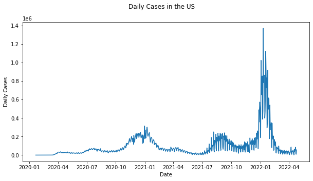

```python
# Adding up all the daily cases from all states per date
totalDailyCasesUS = totalCases_US.groupby(['Date']).agg({'daily_cases': 'sum'})
totalDailyCasesUS.reset_index(inplace=True) # reseting index so that date isn't the index

fig, ax = plt.subplots(figsize=(10,5))
ax.plot(totalDailyCasesUS['Date'], totalDailyCasesUS['daily_cases']) #line plot
plt.xlabel("Date");
plt.ylabel("Daily Cases");
fig.suptitle("Daily Cases in the US");
```

We can see that during periods such as 2020-10 to 2021-03 there was a large spike in daily cases. And an even larger spike came across in 2022-01. Due to this spike however, our $y$-ranges are too large to be able to notice smaller trends. In order to amend this we'll take the log of the cases.

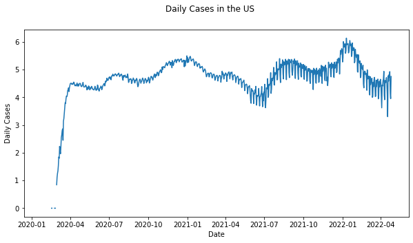

```python
fig, ax = plt.subplots(figsize=(10,5))
totalDailyCasesUS['log'] = np.log10(totalDailyCasesUS['daily_cases'].replace(0, np.NaN))
np.log10(totalDailyCasesUS['daily_cases'].replace(0, np.nan))
ax.plot(totalDailyCasesUS['Date'], totalDailyCasesUS['log'])
plt.xlabel("Date");
plt.ylabel("Daily Cases");
fig.suptitle("Daily Cases in the US");
```

Now we can notice the trend smaller daily cases values more clearly. A thing to note from this graph is that we can see a sharp increase near the start of the pandemic which is not observed anywhere else. Additionally the massive spikes in cases at the start of 2022 is nowhere as extreme as it was in the non-log graph.

#### Demographics

A main relationship we would like to examine is whether the demographics of a state has an association with COVID cases. Certain demographic factors may have a relationship with Covid-19 cases per capita because these demographic factors could relate to how cautious individuals are of the disease, their ability to alter their lives to avoid infection, and the policies their state government put in place to reduce the spread of the disease. As an example of this line of thinking, consider the demographic of age. States with a large number of older individuals may have less Covid-19 cases per capita since these older individuals are more susceptible to severe outcomes from the disease and would thus try harder to avoid infection. State government policies could also reflect this by instituting stricter precautions and lockdown measures.

Since there's numerous demographic columns in our states_demographic dataframe, we'll define a function that plots the variables that we want to show a relationship between.

```python
# getting on the total cases accumulated by 04-25-22
end_date = datetime.datetime.strptime("2022-04-25", '%Y-%m-%d')
datefilter = totalCases_US.loc[totalCases_US['Date'] == end_date].copy()
```

However, before we plot the various demographic factors we want our dependent variable (cases) to be relatively small in range. An issue with just plotting demographic factor by total case is that intuitively states with larger populations will have more cases. And so to avoid having the range of the graph skewed by this, we'll make our dependent variable *cases per capita* instead. This way our $y$-range is $\in [0,1]$ and we can better assses visually whether there is a significant association with an individual factor.

```python
#datefilter= datefilter.drop(9074)
state_demographics = state_demographics.drop(2)


datefilter['cases_per_capita'] = np.NaN
for i, row in datefilter.iterrows():
    s = row["Province_State"]
    population = state_demographics[state_demographics['State'] == s]['Population.2020 Population']
    datefilter.at[i, 'cases_per_capita'] = (row["Cases"]/float(population))

datefilter
```

|  | Province_State | Date | Cases | daily_cases | cases_per_capita |
| --- | --- | --- | --- | --- | --- |
| 824 | Alabama | 2022-04-25 | 1299816 | 679.0 | 0.258707 |
| 1649 | Alaska | 2022-04-25 | 251506 | 0.0 | 0.342936 |
| 3299 | Arizona | 2022-04-25 | 2019174 | 0.0 | 0.282343 |
| 4124 | Arkansas | 2022-04-25 | 835035 | 40.0 | 0.277280 |
| 4949 | California | 2022-04-25 | 9197251 | 6679.0 | 0.232617 |
| 5774 | Colorado | 2022-04-25 | 1378503 | 2963.0 | 0.238755 |
| 6599 | Connecticut | 2022-04-25 | 753836 | 2026.0 | 0.209054 |
| 7424 | Delaware | 2022-04-25 | 261660 | 261.0 | 0.264317 |
| 9899 | Florida | 2022-04-25 | 5942723 | 0.0 | 0.275916 |
| 10724 | Georgia | 2022-04-25 | 2509160 | 0.0 | 0.234240 |
| 13199 | Hawaii | 2022-04-25 | 245035 | 0.0 | 0.168378 |
| 14024 | Idaho | 2022-04-25 | 445670 | 125.0 | 0.242330 |
| 14849 | Illinois | 2022-04-25 | 3122191 | 8155.0 | 0.243683 |
| 15674 | Indiana | 2022-04-25 | 1699213 | 2454.0 | 0.250417 |
| 16499 | Iowa | 2022-04-25 | 762036 | 0.0 | 0.238855 |
| 17324 | Kansas | 2022-04-25 | 774490 | 429.0 | 0.263622 |
| 18149 | Kentucky | 2022-04-25 | 1325805 | 741.0 | 0.294242 |
| 18974 | Louisiana | 2022-04-25 | 1172184 | 551.0 | 0.251663 |
| 19799 | Maine | 2022-04-25 | 242033 | 0.0 | 0.177657 |
| 20624 | Maryland | 2022-04-25 | 1025925 | 1005.0 | 0.166082 |
| 21449 | Massachusetts | 2022-04-25 | 1743980 | 5749.0 | 0.248080 |
| 22274 | Michigan | 2022-04-25 | 2411464 | 0.0 | 0.239296 |
| 23099 | Minnesota | 2022-04-25 | 1445017 | 1158.0 | 0.253223 |
| 23924 | Mississippi | 2022-04-25 | 796840 | 0.0 | 0.269086 |
| 24749 | Missouri | 2022-04-25 | 1420274 | 527.0 | 0.230755 |
| 25574 | Montana | 2022-04-25 | 273569 | 80.0 | 0.252318 |
| 26399 | Nebraska | 2022-04-25 | 479393 | 212.0 | 0.244401 |
| 27224 | Nevada | 2022-04-25 | 710350 | 0.0 | 0.228805 |
| 28049 | New Hampshire | 2022-04-25 | 308446 | 918.0 | 0.223913 |
| 28874 | New Jersey | 2022-04-25 | 2246233 | 1315.0 | 0.241817 |
| 29699 | New Mexico | 2022-04-25 | 521432 | 414.0 | 0.246246 |
| 30524 | New York | 2022-04-25 | 5130561 | 6949.0 | 0.253972 |
| 31349 | North Carolina | 2022-04-25 | 2647650 | 0.0 | 0.253621 |
| 32174 | North Dakota | 2022-04-25 | 240713 | 0.0 | 0.308965 |
| 33824 | Ohio | 2022-04-25 | 2688327 | 0.0 | 0.227835 |
| 34649 | Oklahoma | 2022-04-25 | 1039415 | 0.0 | 0.262521 |
| 35474 | Oregon | 2022-04-25 | 716414 | 2068.0 | 0.169075 |
| 36299 | Pennsylvania | 2022-04-25 | 2809243 | 1072.0 | 0.216051 |
| 37949 | Rhode Island | 2022-04-25 | 369234 | 988.0 | 0.336469 |
| 38774 | South Carolina | 2022-04-25 | 1472093 | 0.0 | 0.287607 |
| 39599 | South Dakota | 2022-04-25 | 237535 | 0.0 | 0.267897 |
| 40424 | Tennessee | 2022-04-25 | 2027209 | 0.0 | 0.293338 |
| 41249 | Texas | 2022-04-25 | 6810953 | 1660.0 | 0.233688 |
| 42074 | Utah | 2022-04-25 | 930558 | 0.0 | 0.284434 |
| 42899 | Vermont | 2022-04-25 | 122341 | 807.0 | 0.190243 |
| 44549 | Virginia | 2022-04-25 | 1694570 | 3302.0 | 0.196326 |
| 45374 | Washington | 2022-04-25 | 1483332 | 0.0 | 0.192508 |
| 46199 | West Virginia | 2022-04-25 | 500228 | 432.0 | 0.278878 |
| 47024 | Wisconsin | 2022-04-25 | 1604375 | 2931.0 | 0.272218 |
| 47849 | Wyoming | 2022-04-25 | 156392 | 0.0 | 0.271113 |

The code below creates a "plot_by" function that allows us to create plots that illustrate the relationship between the cases per capita and a demographic. This function will be used below to create multiple plots and visualize our data.

```python
# Maps state names to their abbreviations
from us_state_abbrev import us_state_to_abbrev
from sklearn.linear_model import LinearRegression
import statsmodels.api as sm
import statsmodels.formula.api as smf

datefilter = pd.merge(datefilter, state_demographics ,left_on='Province_State',right_on='State')
def plot_by(demographic, x_title, title, run_regression):
    states = np.unique(state_demographics['State'])
    datefilter[demographic] = np.NaN

    for i, row in datefilter.iterrows():
        s = row["Province_State"]
        population = state_demographics[state_demographics['State'] == s]['Population.2020 Population'].values
        if (len(population) >= 1) :
            demo = state_demographics[state_demographics['State'] == s][demographic].values[0]
            datefilter.at[i, demographic]= demo

    # Picking colors from a colorwheel for each scatter point
    phi = np.linspace(0, 2*np.pi, len(states))
    x = np.sin(phi)
    y = np.cos(phi)
    rgb_cycle = np.vstack((
            .5*(1.+np.cos(phi)),
            .5*(1.+np.cos(phi+2*np.pi/3)),
            .5*(1.+np.cos(phi-2*np.pi/3)))).T

    x = datefilter[demographic].values.reshape(-1, 1)
    # y = list(datefilter['Cases'].values)
    #y = np.array(cases_per_capita)
    y = np.array(datefilter['cases_per_capita'])
    plt.figure(figsize=(16,8))
    #sns.scatterplot(x=x,y=y,palette="Set2")

    if run_regression:
        linear_regressor = LinearRegression()  # create object for the class
        linear_regressor.fit(x, y)  # perform linear regression
        Y_pred = linear_regressor.predict(x)
        plt.plot(x, Y_pred, color='red')



    plt.scatter(x, y, c=rgb_cycle, s=90)


    # Adding teamID to each scatter point
    for i, txt in enumerate(states):
        plt.annotate(us_state_to_abbrev[txt], (x[i], y[i]))

    plt.ylabel("Covid-19 Cases Per Capita")
    plt.xlabel(x_title)
    plt.title(title)
    plt.show()
    return x,y
```

Below we selected some of the demographics that we felt had the strongest chance of affecting cases per capita and plotted them. We selected population density because we hypothesized the disease would spread easier in dense spaces, percent of population under 18 because younger individuals (who are less susceptible to negative outcomes) would be less cautious about the spread, percent of population older than 65 because older individuals would presumably be more cautious, income because wealthier people may have more means of avoiding infection, education because more educated people might be more aware of the dangers of the disease, and poverty level because impoverished individuals would have less means of escaping infection (these reasons are purely conjecture). We also plotted percent of population that is female as a quasi-baseline. The plots are displayed below.

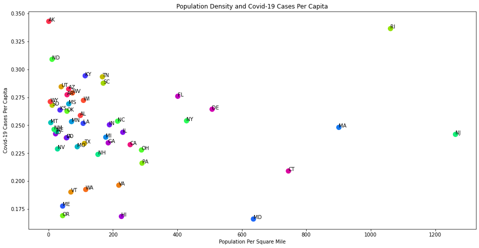

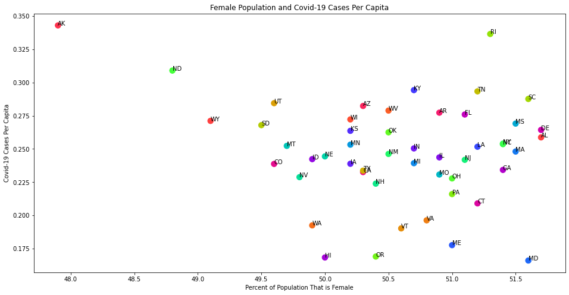

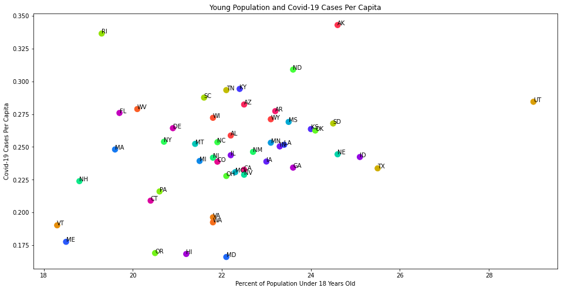

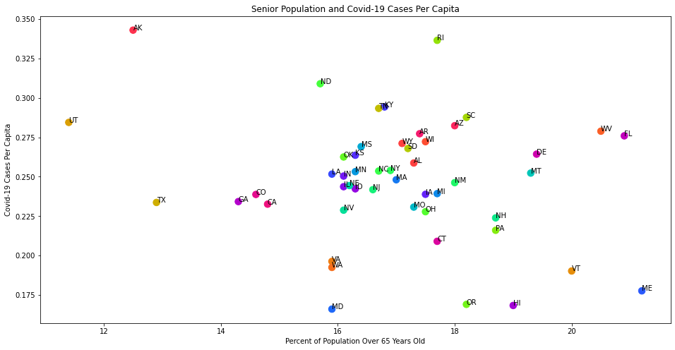

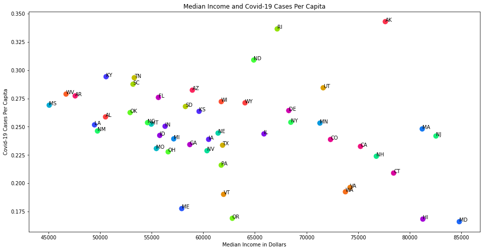

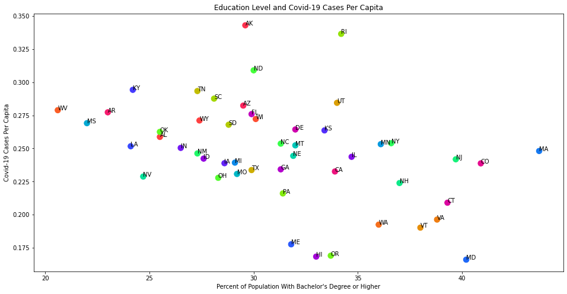

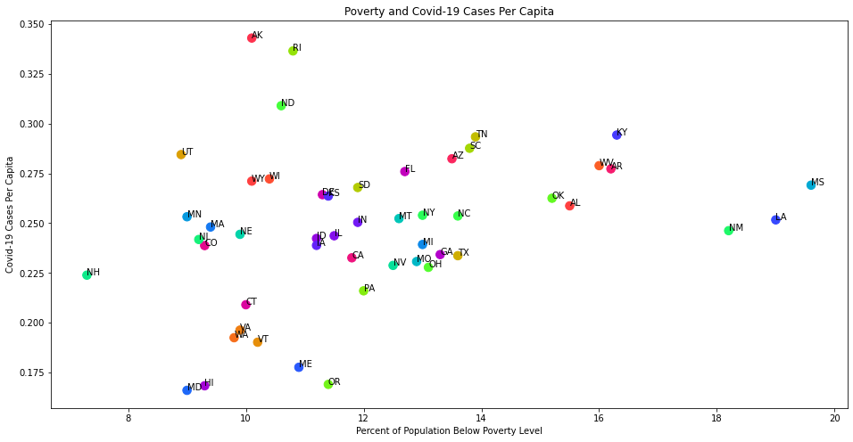

```python
plot_by("Population.Population per Square Mile", "Population Per Square Mile", "Population Density and Covid-19 Cases Per Capita", False)
plot_by("Miscellaneous.Percent Female", "Percent of Population That is Female", "Female Population and Covid-19 Cases Per Capita", False)
plot_by("Age.Percent Under 18 Years", "Percent of Population Under 18 Years Old", "Young Population and Covid-19 Cases Per Capita", False)
plot_by("Age.Percent 65 and Older", "Percent of Population Over 65 Years Old", "Senior Population and Covid-19 Cases Per Capita", False)
plot_by("Income.Median Houseold Income", "Median Income in Dollars", "Median Income and Covid-19 Cases Per Capita", False)
plot_by("Education.Bachelor's Degree or Higher", "Percent of Population With Bachelor's Degree or Higher", \
        "Education Level and Covid-19 Cases Per Capita", False);
plot_by("Income.Persons Below Poverty Level", "Percent of Population Below Poverty Level", "Poverty and Covid-19 Cases Per Capita", False);
```

## Hypothesis Testing and Regression

Looking at the general trend of the scatterplots above, we selected three of the demographics we felt had the strongest effect on cases per capita (just by eyeballing the plots above) and ran a linear regression on them. We decided to run a linear regression for percent of population with a bachelor's degree, median income, and percent of population under eighteen years old. The plots with the line of best fit are outputted below.

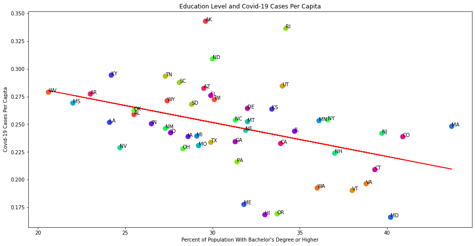

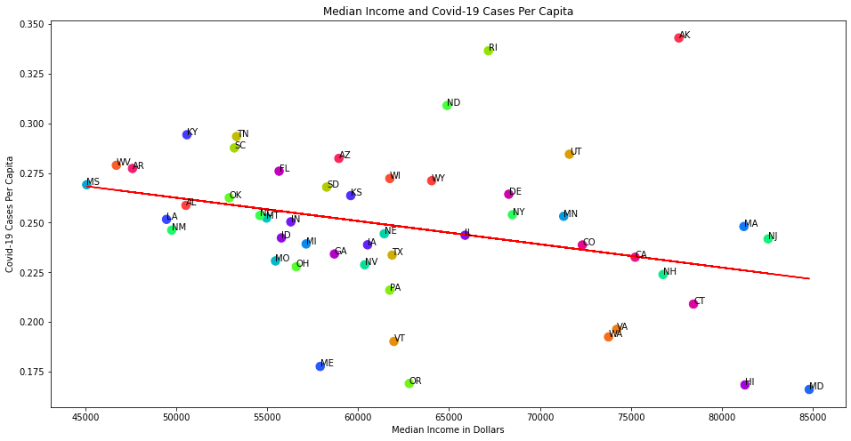

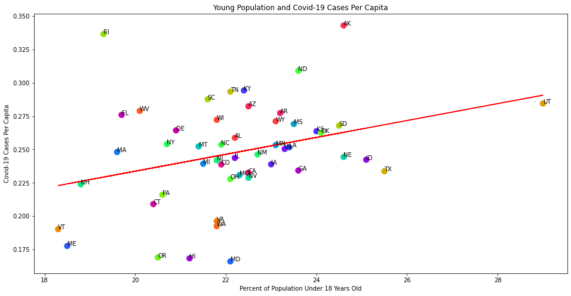

```python
plot_by("Education.Bachelor's Degree or Higher", "Percent of Population With Bachelor's Degree or Higher", \
        "Education Level and Covid-19 Cases Per Capita", True);
plot_by("Income.Median Houseold Income", "Median Income in Dollars", "Median Income and Covid-19 Cases Per Capita", True);
plot_by("Age.Percent Under 18 Years", "Percent of Population Under 18 Years Old", "Young Population and Covid-19 Cases Per Capita", True);
```

Below we use OLS regression to run hypothesis tests on the data to determine the veracity of the relationships. Here we ran OLS regression with the percent of the population who has a bachelor's degree. The p-value was .003, which is less than .05. This means the p-value is significant and we can reject the null hypothesis that there is no relationship between cases per capita and the percent of the population who has a bachelor's degree. Our $\hat{\beta}$ shows that for a 1 percent increase in the percentage of people with bachelor+, the cases per capita decreases by 0.31 percent.

*We also have to rename the colums for the regression to work

```python
datefilter.rename(columns={"Education.Bachelor's Degree or Higher": "college_percentage",\
                                        "Income.Median Houseold Income": "median_income", "Age.Percent Under 18 Years": "youth_percentage"},\
                  inplace = True)

mod = smf.ols(formula='cases_per_capita ~ college_percentage', data=datefilter)
res = mod.fit()
print(res.summary())
```

```
                            OLS Regression Results
==============================================================================
Dep. Variable:       cases_per_capita   R-squared:                       0.173
Model:                            OLS   Adj. R-squared:                  0.155
Method:                 Least Squares   F-statistic:                     10.02
Date:                Mon, 16 May 2022   Prob (F-statistic):            0.00269
Time:                        10:36:58   Log-Likelihood:                 97.084
No. Observations:                  50   AIC:                            -190.2
Df Residuals:                      48   BIC:                            -186.3
Df Model:                           1
Covariance Type:            nonrobust
======================================================================================
                         coef    std err          t      P>|t|      [0.025      0.975]
--------------------------------------------------------------------------------------
Intercept              0.3435      0.031     11.199      0.000       0.282       0.405
college_percentage    -0.0031      0.001     -3.165      0.003      -0.005      -0.001
==============================================================================
Omnibus:                        3.086   Durbin-Watson:                   1.787
Prob(Omnibus):                  0.214   Jarque-Bera (JB):                2.139
Skew:                           0.312   Prob(JB):                        0.343
Kurtosis:                       3.798   Cond. No.                         194.
==============================================================================

Notes:
[1] Standard Errors assume that the covariance matrix of the errors is correctly specified.
```

Below we ran OLS regression with the median income of the state. The p-value was .027, which is less than .05. This means the p-value is significant and we can reject the null hypothesis that there is no relationship between cases per capita and the median income of the state. Our $\hat{\beta}$ shows that for an increase in yearly median income of 10000\$ would decrease cases per capita by 1.171\%.

```python
mod = smf.ols(formula='cases_per_capita ~ median_income', data=datefilter)
res = mod.fit()
print(res.summary())
```

```
                            OLS Regression Results
==============================================================================
Dep. Variable:       cases_per_capita   R-squared:                       0.098
Model:                            OLS   Adj. R-squared:                  0.079
Method:                 Least Squares   F-statistic:                     5.190
Date:                Mon, 16 May 2022   Prob (F-statistic):             0.0272
Time:                        10:36:58   Log-Likelihood:                 94.913
No. Observations:                  50   AIC:                            -185.8
Df Residuals:                      48   BIC:                            -182.0
Df Model:                           1
Covariance Type:            nonrobust
=================================================================================
                    coef    std err          t      P>|t|      [0.025      0.975]
---------------------------------------------------------------------------------
Intercept         0.3211      0.033      9.848      0.000       0.256       0.387
median_income -1.171e-06   5.14e-07     -2.278      0.027    -2.2e-06   -1.38e-07
==============================================================================
Omnibus:                        5.998   Durbin-Watson:                   1.723
Prob(Omnibus):                  0.050   Jarque-Bera (JB):                5.773
Skew:                           0.469   Prob(JB):                       0.0558
Kurtosis:                       4.375   Cond. No.                     3.95e+05
==============================================================================

Notes:
[1] Standard Errors assume that the covariance matrix of the errors is correctly specified.
[2] The condition number is large, 3.95e+05. This might indicate that there are
strong multicollinearity or other numerical problems.
```

Below we ran OLS regression with the percent of the population who is under 18 years old. The p-value was .025, which is less than .05. This means the p-value is significant and we can reject the null hypothesis that there is no relationship between cases per capita and the percent of the population who is younger than 18 years old.

```python
mod = smf.ols(formula='cases_per_capita ~ youth_percentage', data=datefilter)
res = mod.fit()
print(res.summary())
```

```
                            OLS Regression Results
==============================================================================
Dep. Variable:       cases_per_capita   R-squared:                       0.101
Model:                            OLS   Adj. R-squared:                  0.082
Method:                 Least Squares   F-statistic:                     5.391
Date:                Mon, 16 May 2022   Prob (F-statistic):             0.0245
Time:                        10:36:58   Log-Likelihood:                 95.007
No. Observations:                  50   AIC:                            -186.0
Df Residuals:                      48   BIC:                            -182.2
Df Model:                           1
Covariance Type:            nonrobust
====================================================================================
                       coef    std err          t      P>|t|      [0.025      0.975]
------------------------------------------------------------------------------------
Intercept            0.1071      0.061      1.762      0.084      -0.015       0.229
youth_percentage     0.0063      0.003      2.322      0.025       0.001       0.012
==============================================================================
Omnibus:                        2.705   Durbin-Watson:                   1.523
Prob(Omnibus):                  0.259   Jarque-Bera (JB):                1.760
Skew:                           0.288   Prob(JB):                        0.415
Kurtosis:                       3.716   Cond. No.                         260.
==============================================================================

Notes:
[1] Standard Errors assume that the covariance matrix of the errors is correctly specified.
```

#### US vs World

Another thing that we want to know is how the US's cases_per_capita compares to the rest of the world. We want to know how better or worse do we fare in terms of percent cases against the rest of the world. This can give us insight on how well overall we handled COVID in terms of protocols and state-wide safety measures. In order to perform this we have to import some more datasets in which we'll perform the same set of operations on as prior.

Below we'll be importing the global cases from the same Johns Hopkins dataset as well as 2020 Global population data obtained from https://www.kaggle.com/datasets/tanuprabhu/population-by-country-2020

```python
# Getting population for each country as well as the COVID dataset for Global
confirmed_Global = pd.read_csv("datasets/time_series_covid19_confirmed_global.csv")
population_Global = pd.read_csv("datasets/population_by_country_2020.csv")
```

```python
# finding index of first date
idx = next(x for x in confirmed_Global.columns.values if (re.match('(\d{1,2})[/.-](\d{1,2})[/.-](\d{2})$', x)))
idx = np.where(confirmed_Global.columns.values == idx)[0][0]

# melting our dataframe with our identifier variables being everything up to idx+3
confirmed_Global = pd.melt(confirmed_Global, id_vars=confirmed_Global.columns[0:idx])
confirmed_Global.rename(columns={"value": "Cases", "variable": "Date"}, inplace=True)
confirmed_Global['Date'] = pd.to_datetime(confirmed_Global['Date'], format="%m/%d/%y")

# summing all rows with the same country and date
totalCases_Global = confirmed_Global.groupby(['Country/Region', 'Date']).agg({'Cases': 'sum'})
totalCases_Global.reset_index(inplace=True)

# getting only total cases by 04/25/22
datefilter_Global = totalCases_Global.loc[totalCases_Global['Date'] == end_date].copy()

# dropping US from the dataframe
datefilter_Global = datefilter_Global[datefilter_Global['Country/Region'] != "US"]

datefilter_Global['population'] = np.NaN
datefilter_Global['cases_per_capita'] = np.NaN
for i, row in datefilter_Global.iterrows():
    c = row["Country/Region"]
    population = population_Global[population_Global['Country (or dependency)'] == c]['Population (2020)']
    if (len(population) > 0):
        datefilter_Global.at[i, 'population'] = float(population)
        datefilter_Global.at[i, 'cases_per_capita'] = (row["Cases"]/float(population))
datefilter_Global
```

|  | Country/Region | Date | Cases | population | cases_per_capita |
| --- | --- | --- | --- | --- | --- |
| 824 | Afghanistan | 2022-04-25 | 178745 | 39074280.0 | 0.004574 |
| 1649 | Albania | 2022-04-25 | 274828 | 2877239.0 | 0.095518 |
| 2474 | Algeria | 2022-04-25 | 265771 | 43984569.0 | 0.006042 |
| 3299 | Andorra | 2022-04-25 | 41013 | 77287.0 | 0.530658 |
| 4124 | Angola | 2022-04-25 | 99287 | 33032075.0 | 0.003006 |
| ... | ... | ... | ... | ... | ... |
| 160049 | West Bank and Gaza | 2022-04-25 | 656876 | NaN | NaN |
| 160874 | Winter Olympics 2022 | 2022-04-25 | 535 | NaN | NaN |
| 161699 | Yemen | 2022-04-25 | 11818 | 29935468.0 | 0.000395 |
| 162524 | Zambia | 2022-04-25 | 319316 | 18468257.0 | 0.017290 |
| 163349 | Zimbabwe | 2022-04-25 | 247598 | 14899771.0 | 0.016618 |

197 rows × 5 columns

```python
datefilter_Global[datefilter_Global.isna().any(axis=1)]
```

|  | Country/Region | Date | Cases | population | cases_per_capita |
| --- | --- | --- | --- | --- | --- |
| 4949 | Antarctica | 2022-04-25 | 11 | NaN | NaN |
| 23924 | Burma | 2022-04-25 | 612770 | NaN | NaN |
| 33824 | Congo (Brazzaville) | 2022-04-25 | 24079 | NaN | NaN |
| 34649 | Congo (Kinshasa) | 2022-04-25 | 87023 | NaN | NaN |
| 36299 | Cote d'Ivoire | 2022-04-25 | 81898 | NaN | NaN |
| 39599 | Czechia | 2022-04-25 | 3898406 | NaN | NaN |
| 41249 | Diamond Princess | 2022-04-25 | 712 | NaN | NaN |
| 77549 | Kosovo | 2022-04-25 | 227984 | NaN | NaN |
| 87449 | MS Zaandam | 2022-04-25 | 9 | NaN | NaN |
| 121274 | Saint Kitts and Nevis | 2022-04-25 | 5562 | NaN | NaN |
| 122924 | Saint Vincent and the Grenadines | 2022-04-25 | 8394 | NaN | NaN |
| 125399 | Sao Tome and Principe | 2022-04-25 | 5957 | NaN | NaN |
| 139424 | Summer Olympics 2020 | 2022-04-25 | 865 | NaN | NaN |
| 160049 | West Bank and Gaza | 2022-04-25 | 656876 | NaN | NaN |
| 160874 | Winter Olympics 2022 | 2022-04-25 | 535 | NaN | NaN |

There at 15 missing values for cases_per_capita in our dataframe. However, some of these entries are not from a country (i.e Olympics, Diamond Princess). We'll drop the ones that aren't a country and for the others, we'll replace the missing values with the average of the 10 closest countries to the same number of cases. For instance with Antarctica, we'll find the 10 countires that are closest to 11 cases and use the average of those 10 as a replacement. Below is the code to do that.

```python
# dropping non-countries
datefilter_Global.drop(datefilter_Global[datefilter_Global['Country/Region'].str.contains("Olympics")].index, inplace = True)
datefilter_Global.drop(datefilter_Global[datefilter_Global['Country/Region'].str.contains("Diamond Princess")].index, inplace = True)


# getting the index of rows with missing cases_per_capita
missing_index = datefilter_Global[datefilter_Global.isna().any(axis=1)].index

for x in missing_index:
    value = datefilter_Global.loc[x]['Cases']
    num_head = 10;

    while True:
        # getting num_head closests countries
        closests = datefilter_Global.iloc[(datefilter_Global['Cases']-value).abs().argsort()[:num_head]]['cases_per_capita']
        closests = closests[~np.isnan(closests)] # removing NaNs

        if (len(closests) < 10): # do we have 10 non null closests ?
            num_head += 1; # we increment our number of results by 1
        else: # break if yes
            break;

    mean = np.nanmean(closests)
    datefilter_Global.at[x, 'cases_per_capita'] = mean

datefilter_Global.loc[missing_index, :]
```

|  | Country/Region | Date | Cases | population | cases_per_capita |
| --- | --- | --- | --- | --- | --- |
| 4949 | Antarctica | 2022-04-25 | 11 | NaN | 0.044252 |
| 23924 | Burma | 2022-04-25 | 612770 | NaN | 0.130811 |
| 33824 | Congo (Brazzaville) | 2022-04-25 | 24079 | NaN | 0.015925 |
| 34649 | Congo (Kinshasa) | 2022-04-25 | 87023 | NaN | 0.080464 |
| 36299 | Cote d'Ivoire | 2022-04-25 | 81898 | NaN | 0.080454 |
| 39599 | Czechia | 2022-04-25 | 3898406 | NaN | 0.242038 |
| 77549 | Kosovo | 2022-04-25 | 227984 | NaN | 0.101894 |
| 87449 | MS Zaandam | 2022-04-25 | 9 | NaN | 0.040957 |
| 121274 | Saint Kitts and Nevis | 2022-04-25 | 5562 | NaN | 0.042039 |
| 122924 | Saint Vincent and the Grenadines | 2022-04-25 | 8394 | NaN | 0.022435 |
| 125399 | Sao Tome and Principe | 2022-04-25 | 5957 | NaN | 0.043671 |
| 160049 | West Bank and Gaza | 2022-04-25 | 656876 | NaN | 0.143287 |

Now that we have finished cleaning up our dataset we can get into the hypothesis testing.

We'll use a [2-sample hypothesis test](https://www.jmp.com/en_us/statistics-knowledge-portal/t-test/two-sample-t-test.html) here to test the difference in means. In order to do this we'll first have to determine an appropriate test-statistic as what our null $H_0$ and alternate $H_a$ hypotheses are.

An appropriate choice of a null hypothesis here would be to assume that there is no different between the mean cases per capita of the US and the rest of the world. This can be written as: $$H_0: \mu_{US} = \mu_{World} $$ To figure out an appropriate alternate hypothesis lets take a look at our data, especially what both of our means are.

```python
meanUS = np.mean(datefilter['cases_per_capita']) # mean cases_per_capita for the US
meanUS
```

```
0.24775579468154468
```

```python
meanGlobal = np.mean(datefilter_Global['cases_per_capita']) # mean_cases_per_capita for the rest of the world
meanGlobal
```

```
0.1281298279454883
```

Here we can see that the US has a noticably higher cases per capita. Therefore, our data already suggests that our alternate hypothesis should be that: $$H_a: \mu_{US} > \mu_{Global} $$ Thus, if we reject our null hypothesis, we have significant evidence to claim that the US has a higher cases per capita.

As for the test statistic, we use either a $z$ test statistic or a $t$ test statistic depending on what assumptions we can make on our data. An important assumption to check for is normality. This assumption can be checked using a [normal probabiltiy plot](https://en.wikipedia.org/wiki/Normal_probability_plot), which we will do below.

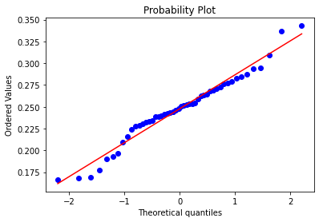

```python
import statsmodels.api as sm
import scipy.stats as stats
import pylab as py

stats.probplot(datefilter['cases_per_capita'], dist="norm", plot=py)
py.show()
```

We see from the normal probability plot that the points fall near the straight line and do show a linear trend. Therefore it is reasonable to assume normality for the US.

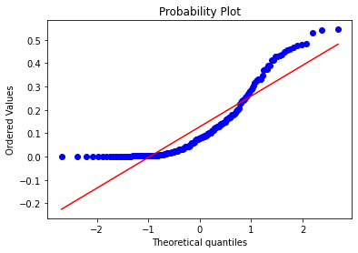

```python
stats.probplot(datefilter_Global['cases_per_capita'], dist="norm", plot=py)
py.show()
```

To obtain our test result we then have to calculate our $p$-value. A $p$-value is defined as the probability (under the assumption that the null hypothesis is true) of finding evidence that is equal to or worse than the test statistic calculated from the given data. Since we're using a $z$-statistic, we'll use the [normal cumulative probability density function](https://www.itl.nist.gov/div898/handbook/eda/section3/eda3661.htm) ($\Phi(z)$) to calculate our p-value. Since our alternate hypothesis is $\geq$ we're performing an upper-tailed test and so our p-value can be expressed as : $$p=1-\Phi(Z)$$ We'll also use the standard significance level $\alpha$ of 0.05. This means that if our calculated $p$-value is less than our $\alpha$ we have significant evidence to reject $H_0$

Below we'll calculate our test-statistic and our p-value.

```python
from scipy.stats import norm # importing normal cdf cuntion

def p_value(us, globe):
    sdUS = np.std(us['cases_per_capita']) # US standard deviation
    sdGlobal = np.std(globe['cases_per_capita']) # Global standard deviation
    n = len(us['cases_per_capita']) # US data size
    m = len(globe['cases_per_capita']) # global data size
    z = (meanUS - meanGlobal)/( (sdUS/np.sqrt(n)) + (sdGlobal/np.sqrt(m)) ) # z-statistic

    p = 1-norm.cdf(z) # calculating our p-value
    return p

p_value(datefilter, datefilter_Global)
```

```
9.769962616701378e-15
```

We see that our $p$-value $\approx 0 < \alpha = 0.05$. Since our p-value is so small, we can conclusively reject our null hypothesis and accept our alternate that the mean cases per capita of the US is larger than the mean cases per capita of the rest of the world.

One thing to note is that we have to remember we're using cases per capita. Therefore when we take the average, countries with higher populations are weighted the same as countries with lower populations. We have 197 countries which means we can have numerous countries with very low case rates which will skew the data towards the lower side even if larger countries such as China, Russia, UK, Canada, etc have a high case rate. One thing we can do is to take the $m \geq 40$ highest population countries and calculate the $p$-value using only those. To see how this method affects our p-value we'll calculate numerous $p$-values with different $m$'s and see whether or not we still reject $H_0$.

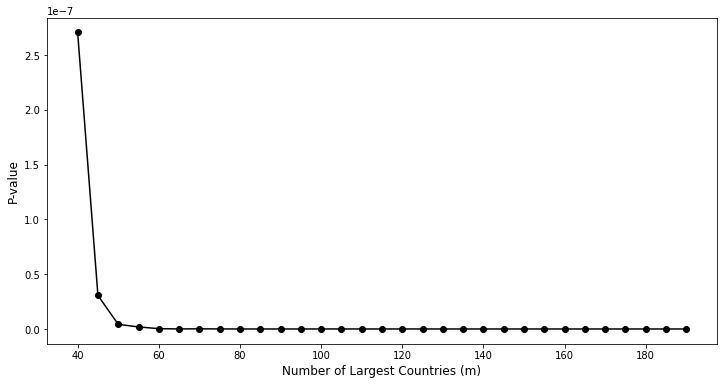

```python
num_max = [i for i in range(40, len(datefilter_Global['cases_per_capita']), 5)] # our different m's (>= 40)
p_values = [] # storing a list of p-values for later plot

# iterating through each m value and adding the calculate p-value
for x in num_max:
    countries_list = population_Global.sort_values(by=['Population (2020)'], ascending=False).head(x)['Country (or dependency)']
    p_values.append(p_value(datefilter, datefilter_Global[datefilter_Global['Country/Region'].isin(countries_list)]))

# plotting our p-value vs m
plt.figure(figsize=(12,6))
plt.xlabel('Number of Largest Countries (m)', fontsize=12)
plt.ylabel('P-value', fontsize=12)
plt.plot(num_max, p_values, '-ok');
```

Here we see that even at all values of $m$ we still conclusively reject the null hypothesis. This shows that even comparing against the $m$ largest countries in the world to reduce the effects of smaller population countries, the hypothesis test still suggets that the US has a larger mean cases per capita. However despite knowing this information we still can't suggest a reason for why this is the case. Note that our cases per capita was calculated using the culumative case counts by 04/25/22. Which means that all the factors such as handling of the initial outbreak, policies enacted during the outbreak, lockdown procedures, etc. are all factored into this case per capita calculation. Thus the only conclusion we can make from our hypothesis test conclusion that the US did worse overall than the rest of the world.

## Communication of Insights and Future Ideas

In regard to the United States demographics portion of our research, it can be concluded that certain demographic factors do have correlations with Covid cases per capita. This was proven through our regressions and hypothesis tests on the relationships between three demographics (income, age, education) and per capita covid cases. All of the p-values were significant and therefore signaled that there was a relationship between the variables. Though we can not prove causation, we can form educated guesses on what causes these relationships. For example, the negative relationship between median income and per capita cases could be because individuals with higher pay are more likely to work in white collar jobs where they can work from home and make themselves less susceptible to infection. The positive relationship between the percent of the population that is under eighteen years old and the per capita cases could be due to young individuals being less cautious of infection, since they are significantly less likely to develop serious symptoms. Lastly, the negative relationship between education and per capita cases could be due to the fact that the highly educated are more likely to be informed on the serious consequences of Covid. This reasoning about the causes of the relationships is purely conjectural.

Because we have proven that certain demographic factors do have relationships with per-capita covid cases, we would recommend that health policymakers study these trends (and attempt to find reasonings for these relationships) in order to better craft policy that can keep all citizens equally safe from Covid-19. Specifically, policy geared towards people of a certain age, income, or education status can be utilized to reduce the spread of Covid. As an example, ads on social media targeting young individuals could be used to attempt to reduce the spread among the younger population. In short, demographic factors should be a consideration when crafting public health policy related to Covid-19.

Additionally, in the previous part we have also shown statistical evidence that the US's cases per capita was significantly higher than the rest of the world. Sadly, that's the only conclusion we can draw from our hypothesis test. However, in future experiments/projects we can focus on a specific part of the US's policies and be more precise on which factors the US did worse in.